# Ex2 - API

April 12, 2016

## Twitter API

Twitter : https://twitter.com.

Connect Orel_Swisa Twitter account.

```
## [1] "Sun Apr 10 22:41:48 2016"
```

```
## [1] "Using direct authentication"
```

Head of 500 tweets with the hashtag **#SuperClasico** from the **Mondial** date

```
## [[1]]
## [1] "Cortesagustina7: RT @JuanRenaudoOk: #Recibimiento #RiverPlate #Superclasico #Increible #ElMasGrandeLejos ⚪️<ed> ½<ed>´´⚪️ https://t.co/zko4oJ5rxC <ed> ½<ed>±"
##
## [[2]]
## [1] "NaveirasJota: RT @JuanRenaudoOk: #Recibimiento #RiverPlate #Superclasico #Increible #ElMasGrandeLejos ⚪️<ed> ½<ed>´´⚪️ https://t.co/zko4oJ5rxC <ed> ½<ed>±"
##
## [[3]]
## [1] "ralphrod52: RT @JuanRenaudoOk: #Recibimiento #RiverPlate #Superclasico #Increible #ElMasGrandeLejos ⚪️<ed> ½<ed>´´⚪️ https://t.co/zko4oJ5rxC <ed> ½<ed>±"
##
## [[4]]
## [1] "YoVivoFutbol: #SuperClasico Video Boca Juniors 3-0 Atlético Rafaela Resumen Goles:  https://t.co/TxKQFVwfPx"
##
## [[5]]
## [1] "angelalealg: https://t.co/jbH6NRL0IW resumen del #Superclasico , increíble #KeylorNavas eres grande , orgullo tico felicidades"
##
## [[6]]
## [1] "Marcoshm8: RT @BasLepelaars: Somehow I feel Madrid will win tonight.... #barrea #superclasico #Cruijff #14 #modric https://t.co/QOenP0QeQW"
```

Most frequently used words in tweets with hashtag #SuperClasico

```
## superclasico   realmadrid          del súperclásico    barcelona
##          325          107          105           96           81
##       madrid
##           70
```

Sum of tweets with hashtag #SuperClasico that contains the word *RealMadrid* (ignore lowwer/uper case)

```
## [1] 131
```

Sum of tweets with hashtag #SuperClasico that contains the word *Barcelona* (ignore lowwer/uper case)

```
## [1] 125
```

## wordcloud of the tweets use in hashtag **#SuperClasico**

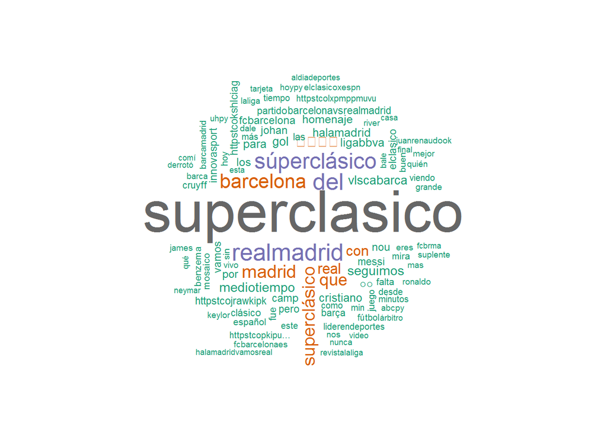

**wordcloud conclusions :**

As we can see the world **“SuperClasico”** is the biggest and in the center of the wordcloud, after it the next word according to the number of times it appears in tweets is **RealMadrid** and only after it we have **Barcelona**.

The result of the game was that **Real Madrid won**, Hence Real Madrid’s fans were more glad and due to they tweeted more. As you can see the word **Cristiano** is also have big appearing in the wordcloud, It resulted in the fact that he scored the most goals in the game, his play determined the final score and brought the victory to Real Madrid.

*Barcelona’s players* : Messi, Neymar, Sourez MSN = Messi Sourez Neymar

*Real Madrid’s players* : Cristiano Ronaldo , Gareth Frank Bale, Benzema BBC= Bale Benzema Cristiano

```
##               Terms
## Terms          superclasico madrid realmadrid barcelona messi neymar
##   superclasico          327     55         59        48    11      1
##   madrid                 55     72          8        29     5      1
##   realmadrid             59      8        107        42     7      0
##   barcelona              48     29         42        85     7      0
##   messi                  11      5          7         7    21      1
##   neymar                  1      1          0         0     1      6
##   cristiano              26      6          4         2     0      0
##   ronaldo                 7      3          3         4     0      0
##   bale                    4      0          0         0     0      0
##   benzema                 7      3          5         4     0      3
##   bbc                     2      0          0         0     0      0
##   msn                     2      0          0         0     0      0
##               Terms
## Terms          cristiano ronaldo bale benzema bbc msn
##   superclasico        26       7    4       7   2   2
##   madrid               6       3    0       3   0   0
##   realmadrid           4       3    0       5   0   0
##   barcelona            2       4    0       4   0   0
##   messi                0       0    0       0   0   0
##   neymar               0       0    0       3   0   0
##   cristiano           30       7    1       3   0   0
##   ronaldo              7      10    0       1   0   0
##   bale                 1       0    7       0   0   0
##   benzema              3       1    0      15   0   0
##   bbc                  0       0    0       0   2   2
##   msn                  0       0    0       0   2   2
```

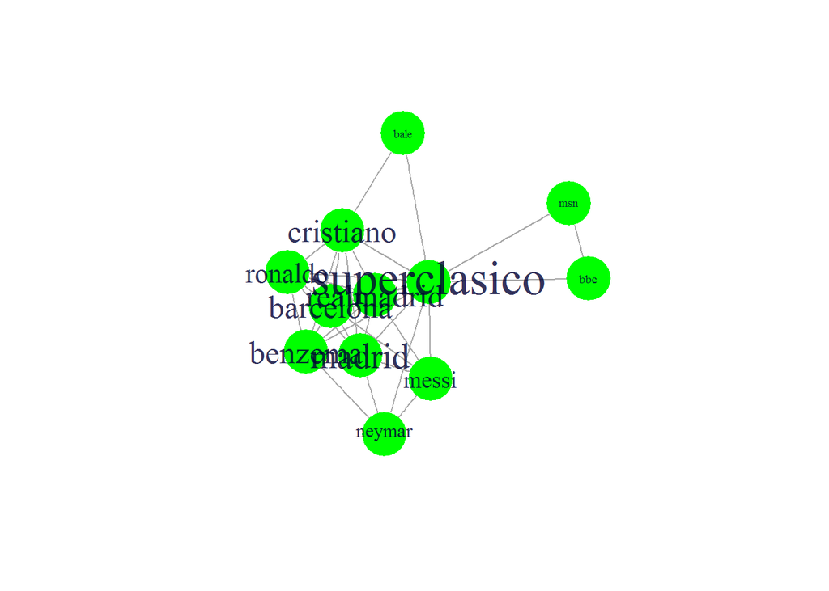

```r
SuperClasico21 <- searchTwitter("#SuperClasico" ,since = '2016-04-02 21:00', until = '2016-04-02 22:00')
length(SuperClasico21)
```

```
## [1] 9
```

```r
SuperClasico22 <- searchTwitter("#SuperClasico" ,since = '2016-04-02 22:00', until = '2016-04-02 23:00')
length(SuperClasico22)
```

```
## [1] 10
```

```r
SuperClasico23 <- searchTwitter("#SuperClasico" ,since = '2016-04-02 23:00', until = '2016-04-02 23:59')
length(SuperClasico23)
```

```
## [1] 4
```

```r
SuperClasico24 <- searchTwitter("#SuperClasico" ,since = '2016-04-03 00:00', until = '2016-04-03 05:00')
length(SuperClasico24)
```

```
## [1] 0
```

```r
SuperClasico5 <- searchTwitter("#SuperClasico" ,since = '2016-04-03 05:00', until = '2016-04-03 06:00')
length(SuperClasico5)
```

```
## [1] 0
```

```r
SuperClasico6 <- searchTwitter("#SuperClasico" ,since = '2016-04-03 06:00', until = '2016-04-03 07:00')
length(SuperClasico6)
```

```
## [1] 0
```

```r
SuperClasico7 <- searchTwitter("#SuperClasico" ,since = '2016-04-03 07:00', until = '2016-04-03 12:00')
length(SuperClasico7)
```

```
## [1] 0
```

```r
SuperClasico12 <- searchTwitter("#SuperClasico" ,since = '2016-04-03 12:00', until = '2016-04-03 13:00')
length(SuperClasico12)
```

```
## [1] 1
```

```r
SuperClasico13 <- searchTwitter("#SuperClasico" ,since = '2016-04-03 13:00', until = '2016-04-03 14:00')
length(SuperClasico13)
```

```
## [1] 1
```

```r
SuperClasico14 <- searchTwitter("#SuperClasico" ,since = '2016-04-03 14:00', until = '2016-04-03 19:00')
length(SuperClasico14)
```

```
## [1] 13
```

```r
SuperClasico19 <- searchTwitter("#SuperClasico" ,since = '2016-04-03 19:00', until = '2016-04-03 23:59')
length(SuperClasico19)
```

```
## [1] 10
```